# MUM 2024-25 Statystyczne porównywanie klasyfikatorów

## Problem

- typowo w badaniach ML proponowany algorytm jest porównywany z innymi
- dla jednego zbioru danych to zasadniczo proste
  - ale koniecznie pamiętać o rozrzucie wyników
- klasyfikator ma pracować dla wielu problemów
  - typowo badacze generują wyniki dla wielu zbiorów i podają uzyskane średnie poprawności
  - nie zawsze podają wariancje wyników **wytłuszczając** najlepsze średnie
  - wariancja zależy od liczby przykładów
  - także od liczby eksperymentów
  - zwykle nie są zrobione żadne testy statystyczne, np. t-testów
- testy statystyczne sprawdzają, czy obliczone wyniki nie są przypadkowe
  - zakładamy hipotezę zerową, że oba klasyfikatory (rozwiązania) są równoważne
  - na podstawie wyników obliczana jest pewna statystyka s stąd pewna wartość $z$
  - wartość zmiennej $z$ pochodzi z ustalonego rozkładu, np. rozkładu normalnego, Studenta, etc.
  - zakładana wartość istotności testu $\alpha$ (zwykle używane $\alpha=0.05$ czy $\alpha=0.10$) mówi, kiedy możemy odrzucić hipotezę zerową o równoważności algorytmów
    - jeśli $z<\alpha$, to hipotezę zerową można odrzucić

## Testy parametryczne a nieparametryczne

- testy parametryczne zakładają, że
  - dane mają rozkład normalny
  - wariancja jest identyczna we wszystkich próbkach
  - jeśli te warunki są spełnione, to testy parametryczne są silniejsze
  - istnieje sporo testów normalności i homoskedastyczności
  - zwykle trudno to zapewnić, stąd korzystamy z testów nieparametrycznych
- testy nieparametryczne nie mają tych wymagań
  - opierają się na miarach porównawczych między wynikami dla zbiorów

## Najczęściej używane metody

- metody użyte w tekstach na ICML 1999-2003 [[Demsar, Statistical comparisons of classifiers over multiple data sets, JMLR 2006]](https://www.jmlr.org/papers/volume7/demsar06a/demsar06a.pdf)

|  | 1999 | 2000 | 2001 | 2002 | 2003 |
| --- | --- | --- | --- | --- | --- |
| Total number of papers | 54 | 152 | 80 | 87 | 118 |
| Relevant papers for our study | 19 | 45 | 25 | 31 | 54 |
| Sampling method [%] |  |  |  |  |  |
| cross validation, leave-one-out | 22 | 49 | 44 | 42 | 56 |
| random resampling | 11 | 29 | 44 | 32 | 54 |

[output not shown]

- wielu badaczy wzywa by korzystać także z innych miar, np. AUC
- t-testy wykonywane są w kilku postaciach: porównanie tylko dwóch metod, wprowadzana metoda względem pozostałych, każda z każdą
  - mimo niebezpieczeństwa wielu porównań, poprawka Bonferroniego jest rzadko stosowana
- podejście nieparametryczne przez zliczanie zwycięstw/remisów/porażek jest stosowane podobnie
  - tylko niektórzy zliczają jedynie istotne różnice
- wiele artykułów nie podaje metod samplowania, stąd porównania w tabeli trzeba brać z ostrożnością

## Porównania między dwoma klasyfikatorami

- niektórzy uśredniają wyniki dla wielu domen
  - jeśli wyniki dla różnych danych nie są porównywalne, to ich średnie są bez sensu
- średnie są bardzo podatne na outliery
  - świetne wyniki na jednym zbiorze, wyrównują słabe wyniki na innym

### sparowane t-testy

- częstą metodą jest porównanie wyników klasyfikatorów parami dla kolejnych zbiorów
  - niech $c_i^1$ i $c_i^2$, $d_i=c_i^2-c_i^1$ będą wynikami i różnicą na i-tym spośród N zbiorów
  - t statystyki są liczony jako $\bar{d}/\sigma_{bar{d}}$ i mają rozkład Studenta
  - jednak próbka zbiorów powinna być wystarczająco duża, zwykle ponad 30

### test rangowy Wilcoxona

- alternatywą jest test nieparametryczny, w którym brane są pod uwagę rangi różnic między wynikami
- niech $d_i$ będzie różnicą wyników, jak wyżej
- różnice są rangowane zgodnie z ich bezwzględną wartością
  - rangi w przypadku remisów są uśredniane, np. dwa klasyfikatory o równej randze 1, czyli zajmujące miejsca 1 i 2, mają uśrednioną rangę 1.5
- definiujemy rangi $R^+$ gdzie drugi algorytm był lepszy $$R^+=\sum_{d_i>0}rank(d_i)+\frac{1}{2}\sum_{d_i=0}rank(d_i)$$
- analogicznie $R^-$ gdzie pierwszy był lepszy $$R^-=\sum_{d_i<0}rank(d_i)+\frac{1}{2}\sum_{d_i=0}rank(d_i)$$
  - rangi dla remisów są równomiernie rozdzielane
  - niech $T=min(R^+,R^-)$ będzie mniejszą z tych sum
- teraz wyliczamy zmienną $z$ gdzie $N$ jest liczbą zbiorów $$z=\frac{T-\frac{1}{4}N(N+1)}{\sqrt{\frac{1}{24}N(N+1)(2N+1)}}$$ która będzie miała rozkład normalny
  - dobrą miarą do użycia jest AUC
  - dla $\alpha=0.05$ hipoteza zerowa może być odrzucona jeśli $z<-1.96$
- test Wilcoxona jest sensowniejszy od t-testu, ponieważ zakłada porównywalność różnic, jednak tylko jakościowo
- nie zakłada rozkładów normalnych różnic
- outliery mają mniejszy wpływ na wyniki

### porównania liczby zwycięstw / porażek / remisów

- wygodne
- w przypadku wielu algorytmów, wyniki mogą być zorganizowane w postaci tabeli
- liczba zwycięstw ma rozkład dwumianowy, wartości krytyczne dla $\alpha=0.05$ i $\alpha=0.10$ są w tabeli

| #zbiorów | 5 | 6 | 7 | 8 | 9 | 10 | 11 | 12 | 13 | 14 | 15 | 16 | 17 | 18 | 19 | 20 | 21 | 22 | 23 | 24 | 25 |
| --- | --- | --- | --- | --- | --- | --- | --- | --- | --- | --- | --- | --- | --- | --- | --- | --- | --- | --- | --- | --- | --- |
| $w_{0.05}$ | 5 | 6 | 7 | 7 | 8 | 9 | 9 | 10 | 10 | 11 | 12 | 12 | 13 | 13 | 14 | 15 | 15 | 16 | 17 | 18 | 18 |
| $w_{0.10}$ | 5 | 6 | 6 | 7 | 7 | 8 | 9 | 9 | 10 | 10 | 11 | 12 | 12 | 13 | 13 | 14 | 14 | 15 | 16 | 16 | 17 |

- jeśli mamy 20 zbiorów, to aby algorytm był znacząco lepszy dla $\alpha=0.05$, to musi wygrywać co najmniej dla 15 zbiorów
- wielu autorów wykorzystuje tylko *znaczące* zwycięstwa, inne oznaczając jako remisy
  - testy statystyczne wykorzystują jedynie prawdopodobieństwo wygranej
  - wykorzystanie *znaczących* zwycięstw powoduje, wbrew pozorom, że procedura jest mniej niezawodna — potrzeba znacznie więcej wygranych, które mogą być losowe

## Porównania dla wielu klasyfikatorów

- żaden z powyższych nie nadaje się do porównywania wielu algorytmów
- wykonanie spowoduje wyniki typu
  - A był znacząco lepszy do B i C $A>B, A>C$
  - B był znacząco lepszy do D $B>D$
  - E i A były znacząco lepsze od F $E>F, A>E$
  - poza tym były równe

    co nie daje żadnych informacji

### ANOVA

- dzieli łączną zmienność miedzy klasyfikatory i stosuje procedury podobne do t-testu
- niestety zakłada, że próbki danych są z rozkładów normalnych
- zakłada jeszcze porównywalność wyników, o co nawet trudniej
- jest oprogramowanie

### test Friedmana

- nieparametryczny wykorzystujący rangowanie
  - dla każdego zbioru danych są znajdywane rangi wyników dla każdego algorytmu (najlepszy ranga 1, drugi 2, itd.)
  - niech $r_i^j$ jest rangą j-tego algorytmu dla i-tego spośród N zbiorów
  - wyliczamy średnią rangę $R_j=\frac{1}{N}\sum_ir_i^j$ dla $k$ klasyfikatorów
  - stąd jest wyliczana statystyka Friedmana $\chi_F^2$ $$\chi_F^2=\frac{12N}{k(k+1)}\left[\sum_jR_j^2-\frac{k(k+1)^2}{4} \right]$$ gdzie $k-1$ jest liczbą stopni swobody (zwykle $N>10$, $k>5$)
    - liczba stopni swobody jest liczbą zmiennych wartości w statystyce, tutaj dla $k$ będącego liczbą klasyfikatorów
  - poprawiona statystyka ma postać $$F_F=\frac{(N-1)\cdot\chi_F^2}{N(k-1)-\chi_F^2}$$
    - dla 20 zbiorów i 5 klasyfikatorów, bedziemy mieli $(5-1)(20-1)=76$ stopni swobody
  - wartości krytyczne dla statystyki Friedmana są w tabelach statystycznych
  - jeśli hipoteza zerowa (tzn., że dwa klasyfikatory są równe) jest odrzucona, należy policzyć kolejne wartości dla testu Nemenyi $$CD=q_\alpha\sqrt{\frac{k(k+1)}{6N}}$$ (critical difference) które pokazują czy dwa algorytmy są statystycznie różne jeśli średnia CD różni się co najmniej o wartość w tabeli

| #klasyfikatorów | 2 | 3 | 4 | 5 | 6 | 7 | 8 | 9 | 10 |
| --- | --- | --- | --- | --- | --- | --- | --- | --- | --- |
| $q_{0.05}$ | 1.960 | 2.343 | 2.569 | 2.728 | 2.850 | 2.949 | 3.031 | 3.102 | 3.164 |
| $q_{0.10}$ | 1.645 | 2.052 | 2.291 | 2.459 | 2.589 | 2.693 | 2.780 | 2.855 | 2.920 |

### Graficzna prezentacja wyników

- wyniki mogą być łatwo zaprezentowane graficznie
- jest ogólnie dostępny pakiet `scmamp` (w R)

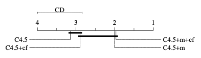

#### to oczywiście nie są wszystkie metody porównywania

Rozszerzenie pracy Demsar dla innych przypadków w [[Garcia, Herrera *An extension on "Statistical comparisons of classifiers over multiple data sets" for all pairwise comparisons* JMLR 2008]](https://www.jmlr.org/papers/volume9/garcia08a/garcia08a.pdf)